# HW 1: Анализ и улучшение авиаперевозок

Мекшун Тихон, tdmekshun

## Задача

на основе данных (и выданных вопросов) постараться выяснить:

- какие проблемы есть в авиаперевозках
- какие улучшения можно предложить на основе выводов по данным

#### Загрузка данных и преобразование

| id | questions |
| --- | --- |
| 1 | -Какие типы путешественников (type_traveller) поставили самые низкие оценки по критерию оценок за обслуживание в аэропорте (aeroport staff)? |
| 2 | -Где доля полетов в экономе выше -- в BOEING или в AIRBUS? |
| 3 | -Какие аэропорты рекомендуют чаще, те, в которых есть лаунжи бизнесс-класса, или те, в которых их нет? |

### Вопросы

#### Вопрос 1

**Вопрос:** Какие типы путешественников (type_traveller) поставили самые низкие оценки по критерию оценок за обслуживание в аэропорте (airport staff)?

**Данные:** для ответа на вопрос нужны таблицы airport

```
##   type_traveller airport_staff_rating
## 1   Solo Leisure                    1
## 2  FamilyLeisure                    1
## 3       Business                   10
```

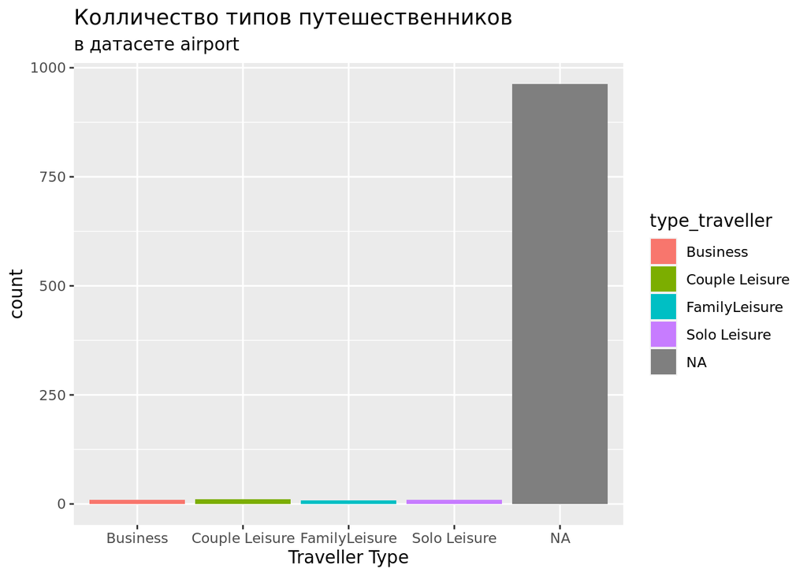

**Ответ:** Solo Leisure, Family Leisure

**Вывод:** Основываясь на данных, меньше всего обслуживанием в аэропорте довольны пассажиры типа: Solo Leisure, Family Leisure. Однако, данный вывод сделан на 3 оценках известных типов пассажиров с известной оценкой за обслуживание в аэропорте, поэтому вывод может не отражать реальной картины. Как показывает столбчатый график, в датасете airport больше неизвестных типов путешественников, а известных - очень мало. Чтобы оценить какой тип меньше всего доволен обслуживанием в аэропорте нужно вписать большее данных о типе путешественника в датасет airport. А на основе имеющихся данных можно узнать у самой недовольной части как можно улучшить обслуживание аэропорта.

#### Вопрос 2

**Вопрос:** Где доля полётов в экономе выше -- в BOEING или в AIRBUS?

**Данные:** для ответа на вопрос нужны таблицы seat

```
## # A tibble: 2 × 3
##   aircraft counts fraction
##   <chr>     <int>    <dbl>
## 1 airbus       29     19.6
## 2 boeing       52     35.1
```

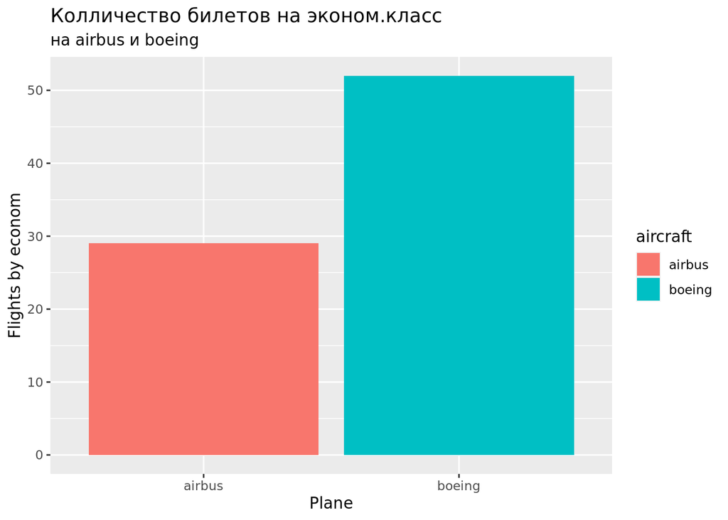

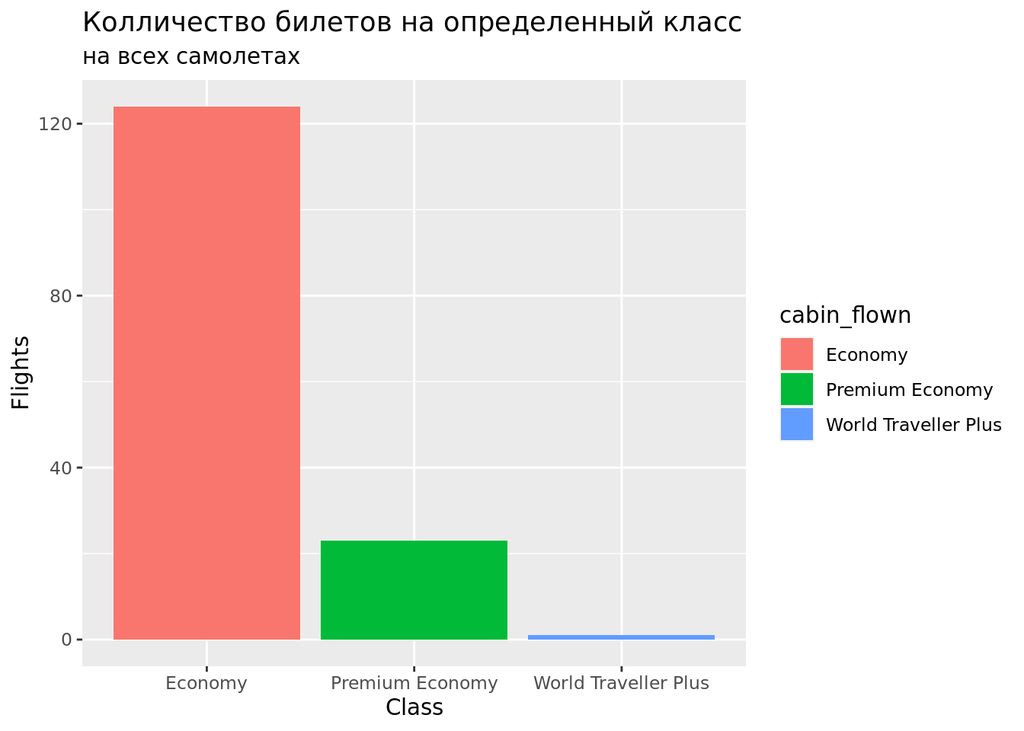

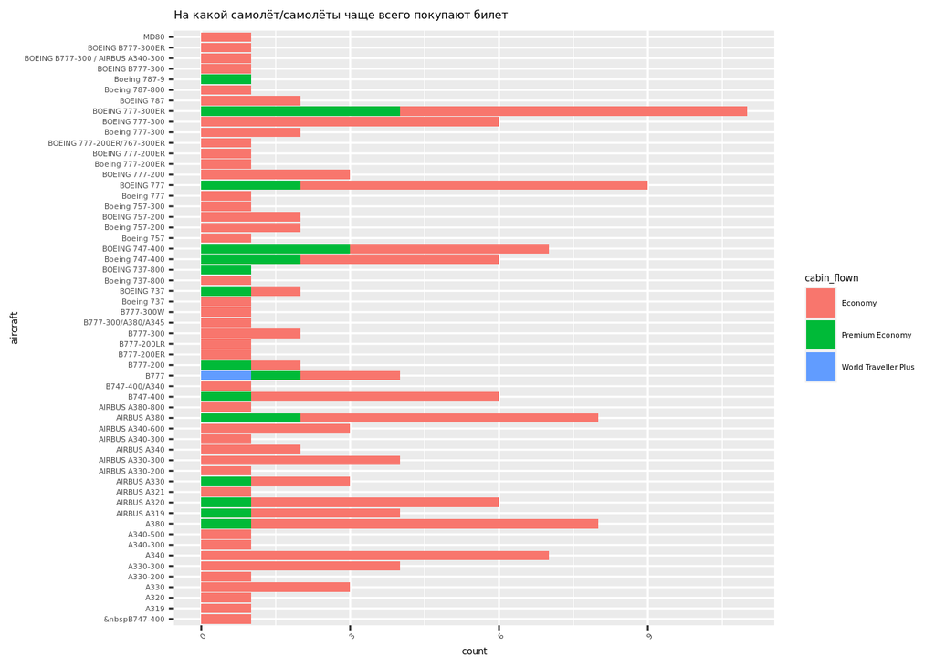

```
## # A tibble: 54 × 2
##    aircraft         count_ticket
##    <chr>                   <int>
##  1 A340                        7
##  2 A380                        7
##  3 BOEING 777                  7
##  4 BOEING 777-300ER            7
##  5 AIRBUS A380                 6
##  6 BOEING 777-300              6
##  7 AIRBUS A320                 5
##  8 B747-400                    5
##  9 A330-300                    4
## 10 AIRBUS A330-300             4
## # … with 44 more rows
```

**Ответ:** BOEING

**Вывод:** Можно сделать вывод о том, что на самолёты модели Boeing чаще покупают билеты в эконом.класс, чем на самолёты модели airbus. Более того, второй график показывает, что эконом.класс - это самый популярный выбор вообще. Более того, как показывает последний график, чаще всего люди летают на самолёте boeing 777-300ER, в котором одна из самых больших долей пассажиров эконом.класса, так и самая большая доля премиум.эконома. А самолёты куда покупают чаще всего билеты эконом.класса это: A340, A380, BOEING 777 и BOEING 777-300ER (лидер по колличеству билетов в принципе). Что касается практических методов, то нужно вспомнить, что не человек полностью решает на какой модели самолёта ему лететь, а авиакомпания у которой есть купленные самолёты. Значит, можно построить теорию о том, что A340, A380, BOEING 777 и BOEING 777-300ER -- самые популярные купленные модели у авиакомпаний и попытаться узнать почему: дело в цене или, например, дело в обслуживании самолёта. Например, если заказчик - будущая авиакомпания, то можно представить эти данные, чтобы они определились с покупкой оптимального варианта.

### Вопрос 3

**Вопрос:** Какие аэропорты рекомендуют чаще, те, в которых есть лаунжи бизнесс-класса, или те, в которых их нет?

**Данные:** для ответа на вопрос нужны таблицы lounge, airport

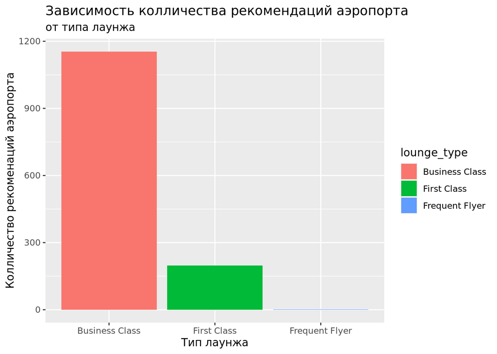

```
## # A tibble: 6 × 2
##   airport                 count_rec
##   <chr>                       <int>
## 1 London Heathrow Airport         2
## 2 Sydney Airport                  2
## 3 NA                              2
## 4 Chicago O'Hare Airport          1
## 5 Dalian Airport                  1
## 6 Dubai Airport                   1
```

```
## # A tibble: 6 × 2
##   airport                      count_rec
##   <chr>                            <int>
## 1 London Heathrow Airport             13
## 2 Istanbul Ataturk Airport             9
## 3 Bangkok Suvarnabhumi Airport         8
## 4 Colombo Airport                      7
## 5 Dubai Airport                        6
## 6 Los Angeles Lax Airport              6
```

**Ответ:** В которых лаунж бизнесс-класса есть.

**Вывод:** Люди охотнее рекомендуют аэропорты с лаунжем бизнесс-класса, чем аэропорты без него. Получается лаунж бинесс-класса влияет на общее впечатления и дальнейшего пребывания в аэропорту. Соответвенно, если заказчик - потенциальный аэропорт, то можно порекомендовать ему, на основе данных, сделать в первую очередь лаунж бизнесс-класса, а не первого класса или не делать его вовсе. А существующим аэропортам можно посоветовать улучшить сервис первого класса. Две последние таблицы показывают колличество рекомендаций бизнес и первого класса. Значит, пассажиров может что-то не устраивать в лаунже первого класса или можно выяснить причину непопулярности первого класса. Так же, стоит отметить, что Heathrow является лидером в обоих сравнениях, значит можно изучить его, например, в качестве анализа конкурента.

### Дэшборд

Полученные выводы обобщены в виде дэшборда со следующими элементами

**Элемент 1:** - вид: Таблица - ответ на вопрос: 1 - обоснование: в данном случае обычная частотная таблица наглядно показывает тип путешественника и его оценки за обслуживание. Наглядный и простой способ визуализации. Данная таблица даёт легко понять какой тип, какую оценку поставил.

**Элемент 2:** - вид: график - ответ на вопрос: 1 - обоснование: в данном случае я хотел сконцентрировать внимание на проблему недостатка данных, столбчатая диаграмма наглядно показывает колличество тех или иных типо путешественников в таблице. Самая высокое значение наглядно показывает недостаток данных, ведь дело не в том, что много пропущенных значений, но в том, что данных в принципе мало.

**Элемент 3:** - вид: таблица - ответ на вопрос: 2 - обоснование: в данном случае таблица показывает колличество перевозок на самолётах модели airbus и boeing, а так же их процент по отношению ко всем полётам в датасете. Использовал таблицу для наглядной визуализации данных, где видно как и колличество, так и процент, дабы избежать путанницы и не вводить в заблуждение, например, когда полётов мало, процент становится больше и не отображает реальной картины. За основу был взять датасет seat, дело в том, что если есть отзыв на сидение в самолёте, значит пользователь в нем был и он на нем летал.

**Элемент 4:** - вид: график - ответ на вопрос: 3 - обоснование: Я выбрал график для того, чтобы показать лаунж какого класса принесёт больше всего рекомендаций для аэропорта в целом, а не только рекомендации за сам лаунж. Иначе говоря, этот график показывает, что больше всего рекомендаций аэропорта от пользователей приносит лаунж именно бизнесс-класса, а не иные. Вместо таблицы, которая тоже будет понятной, график выглядит более выигрышным за счёт того, что он больше показывает разницу и лидерство лаунжей бизнесс-класса, а так же "нестостоятельность" frequent flyer. Стоит так же отметить, что некоторые аэропорты имеют несколько лаунжей.

### Общие выводы

Что касается улучшения авиаперевозок и общих выводов.

а)Наблюдение в первом вопросе говорит о том, что наблюдений для улучшения сервиса обслуживание аэропорта недостаточно. Можно попытаться вяснить, почему люди не ставят оценки качеству обслуживание аэропорта и/или почему они не указывают свой тип.

в)Наблюдения в третьем вопросе даёт знание о том, что, чем лучше лаунж бизнесс-класса, тем больше шанс рекомендации аэропорта, так же, что не мало важно хороший лаунж -- повышает впечатление от всего времяпрепровождения в аэропорту. Также, можно заняться анализом лаунжа heathrow airport, как самый рекомендованный лаунж и аэропорт, чтобы понять его особенность и почеп=му люди его рекомендуют.